# Poisson and Exponential Distributions

# Exponential Distribution

The exponential distribution is a *continuous* distribution that, like the Poisson distribution, also relates to a **Poisson process**.

Whereas the *Poisson* describes the **number of events** that occur in a given period of time, the *exponential* describes **the length of time elapsed** between consecutive events. You can also think of this as the *waiting time* **until the first observed event**.

Examples:

- Radioactive decay (time to the first emission, given a particular rate of decay)
- Type II survivorship (where mortality rates are about the same at any age)
- Battery life (for a given failure rate)

## PDF and CDF

The exponential distribution describes the density of waiting times (“failures”) before the next Poisson event. For a random variable that follows this distribution, we write $T$ ~ $EXP(\lambda)$. The **PDF** is:

$$f(t) = \lambda e^{-t\lambda}$$
where $\lambda > 0$ and $t \ge 0$.

The expected value $E(T)$ (the mean) and standard deviation are both $1/\lambda$:

$$\mu = \sigma = 1/\lambda\ \ ;\ \ \sigma^2 = (1/\lambda)^2 = 1/\lambda^2$$

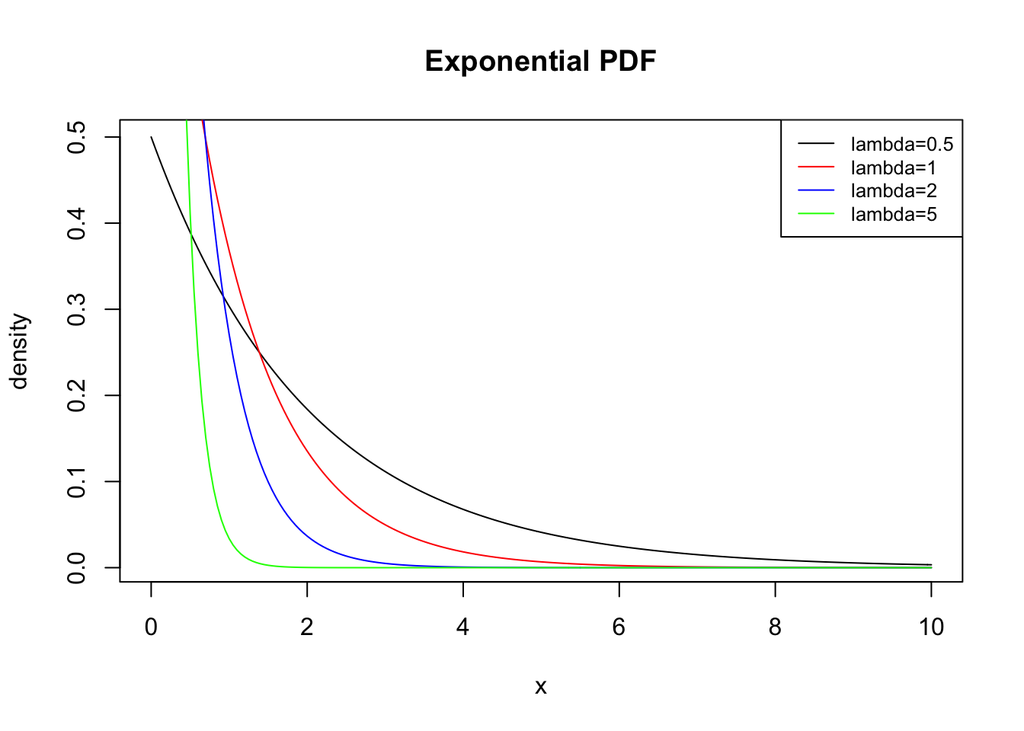

```r
interval.exp<-seq(0, 10, 0.05)
plot(interval.exp,dexp(interval.exp,rate=0.5),type = "l", xlab="x",ylab="density", main="Exponential PDF")
lines(interval.exp,dexp(interval.exp,rate=1),col="red")
lines(interval.exp,dexp(interval.exp,rate=2),col="blue")
lines(interval.exp,dexp(interval.exp,rate=5),col="green")
legend("topright", legend=c("lambda=0.5","lambda=1","lambda=2","lambda=5"),
       col=c("black"," red", "blue", "green"), lty = 1, cex=0.8)
```

The **CDF** has a closed form that does not require integration:

$$F(t) = \int_0^\infty \lambda e^{-\lambda t}dt = 1 - e^{-t\lambda}$$

If we change the name of our random variable to $x$, then we have the probability that a Poisson event occurs within a timespan of zero to $x$:

$$Pr[X \le x] = 1-e^{-x\lambda}$$

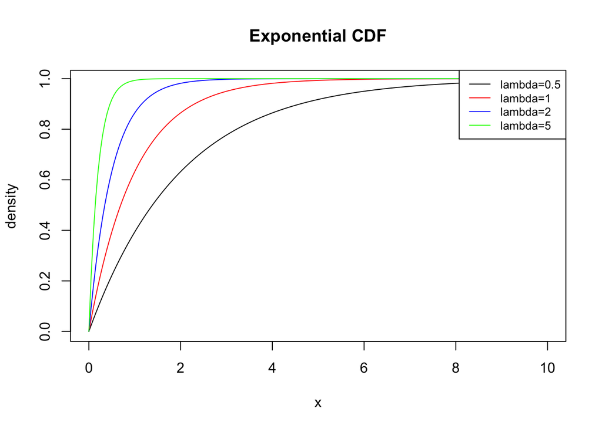

```r
interval.exp<-seq(0, 10, 0.05)
plot(interval.exp,pexp(interval.exp,rate=0.5),type = "l", xlab="x",ylab="density", main="Exponential CDF")
lines(interval.exp,pexp(interval.exp,rate=1),col="red")
lines(interval.exp,pexp(interval.exp,rate=2),col="blue")
lines(interval.exp,pexp(interval.exp,rate=5),col="green")
legend("topright", legend=c("lambda=0.5","lambda=1","lambda=2","lambda=5"),
       col=c("black"," red", "blue", "green"), lty = 1, cex=0.8)
```

The probability that a Poisson event happens *within the interval* between $x_1$ and $x_2$ is:

$$Pr[x_1 < X \le x_2] = F(x_2) - F(x_1) = (1-e^{-x_2\lambda})- (1 - e^{-x_1\lambda})$$

### Survivorship

The **survivorship**, or the length of time *before* something happens, is the same as probability that the time to a Poisson event is *greater* than $x$:

$$Pr[X > x] = 1 - (1 - e^{-x\lambda}) = e^{-x\lambda}$$

### Example: SNVs

Here, our random variable $x$ represents an **interval** of *time* or *space* (vs. the number of events per interval of time). These questions are really just the flip side of the same coin!

**Note:** For the Exponential function family `exp()` in R, $\lambda$ is called the **rate**. Here the rate of SNV’s is 1.5 per kb, so we use `rate=1.5`, where 1kb is “1” unit. Alternatively, we can use `rate=0.0015`, where the unit is 1nt.

$\Rightarrow$ *What is the average number of nt within which we would expect to find one SNV?*

**Answer**

```r
# EXP(X) = 1 / rate
1/1.5         # this is the number of kb since unit size is 1kb
```

```
## [1] 0.6666667
```

```r
(1/1.5)*1000  # we need to multiply by 1000 to get result in nt
```

```
## [1] 666.6667
```

```r
1/(1.5/1000)  # or convert to 0.0015 per nt unit
```

```
## [1] 666.6667
```

$\Rightarrow$ *What is the probability of an SNV occurring somewhere within 1000 nt? (I.e. what is the probability that a span of 1kb will contain at least one SNV?)*

**Answer**

$$Pr[X \le 1000] = 1 - e^{-x\lambda} = 1-e^{-1000*1.5} = 1-e^{-1.5} = 0.777$$

```r
pexp(1, 1.5, lower.tail=T)           # P of finding at least 1 per 1000nt unit
## [1] 0.7768698
pexp(1000,rate=0.0015, lower.tail=T) # same: P from 0-1000 for unit=1nt
## [1] 0.7768698
```

Notice that asking for the probability of finding *at least one* SNV per 1000nt using the Exponential, or asking the probability of *NOT finding 0* in 1000nt using the Poisson, are two ways of asking the same question:

```r
# P of NOT finding 0 (different way to say the same thing)
ppois(0, 1.5, lower.tail=F)
```

```
## [1] 0.7768698
```

$\Rightarrow$ *What is the probability that a span of 1000nt (1kb) will contain NO SNV’s? (I.e. what is the probability of NOT finding a single SNV in 1000nt?)*

**Answer**

This is the same as asking for the survivorship, or the *upper-tail* probability of finding at least one within 1000 nt.

$$P(X > 1000) = 1 - P(X \le 1000) = e^{-x\lambda} = e^{-1.5} = 0.223$$

```r
# P of finding a span of 1000 bases that contains no SNV
# (i.e., P of not finding an SNV within 1kb)

# these are all equivalent
exp(-1.5)
## [1] 0.2231302
pexp(1, rate=1.5, lower.tail=F)  # 1 unit at rate = 1.5/unit
## [1] 0.2231302
pexp(1000, 0.0015, lower.tail=F) # same: 1000 units at rate = 0.0015/unit
## [1] 0.2231302
1-pexp(1000,rate=0.0015)
## [1] 0.2231302
```

The survivorship is the same as $P(X=0)$ for the Poisson distribution with $\lambda=1.5$ and $t=1$:

```r
ppois(0, lambda=1.5, lower.tail=T)
```

```
## [1] 0.2231302
```

```r
# but this is not the same, because this distribution has a different shape!
ppois(0,0.0015)
```

```
## [1] 0.9985011
```

# Relationships between distributions

### Poisson and Exponential distributions

The Poisson is a discrete distribution describing the *number of events per unit time*, and the exponential is a continuous distribution describing the *length of time between events*. For a Poisson process, then, if events happen at a rate of $\lambda$ per unit time on average, an average of $\lambda t$ events will occur per $t$ unit of time.

#### Classic example: Radioactive decay

The decay of radioactive isotopes is a Poisson process, since radioactive isotopes have a constant half-life, and each successive emission is independent of the last one. The Poisson and exponential are complementary ways of describing this process.

- The slower the decay rate (longer half-life), the larger the time interval between observed events (exponential), and the fewer events observed per unit time (Poisson).
- The probability of time elapsed between decay events follows a continuous exponential distribution.
- The probability of detecting a certain number of decay events per unit time with a scintillation counter follows a discrete Poisson distribution.

#### Survival function

The *survival function* is the complement of the CDF of a particular distribution. If the CDF is $F(X) = P(X \le x)$, then the **survivorship** is $P(X > x) = 1 - F(X)$.

For a Poisson distribution $P(X = x) = \frac{e^{- \lambda t}(\lambda t)^x}{x!}$, $P(X = 0) = e^{-\lambda t}$ is the probability of *no* events within $t$ units of time. This is the same as the survivorship, or the probability that the time $T$ to the *first occurrence* exceeds $t$:

$$P(T > t) = P(X = 0 | \mu = \lambda t) = e^{-\lambda t}$$

You can see that this is just one minus the exponential CDF, which gives the total probability that an event *does* occur within an interval of time $t$:

$$P(T \le t) = 1 - P(X = 0 | \mu = \lambda t) = 1 - e^{-\lambda t}$$

For example, the *exponential survivorship* function describes situations where the *probability of mortality is the same for all individuals in a population*, since the rate of events is always the same for a Poisson process. In other words, the chance of dying is independent of age! This is not true for mammals, but it is true of some birds, rodents, lizards, and sea animals.

### Poisson approximation of the Binomial distribution

The Poisson is the **limiting** case of a Binomial distribution for **rare** events. That is, a Poisson with parameter$\lambda = np$ approximates the Binomial when $n$ is large and $p$ is small.

For example, let’s consider hits on a website. This could be modeled as a Binomial distribution with a Bernoulli trial every minute for an hour, with $n=60$. If $p=0.1$, this would be the same as a Poisson distribution with 6 events per hour, i.e. $\lambda=6$.

The Poisson has some advantages over the Binomial:

- The Poisson can contain more than one event per unit interval (whereas the binomial only handles one, since it describes Bernoulli trials, which only have a binary outcome)
- It can be easier to work with the Poisson since it has only one parameter instead of two.

Starting with the Binomial probability, it can be shown that the limit of $P(x)$ as $n$ goes to infinity and $p$ goes to 0 is the equation for the Poisson distribution. Setting $p=\frac{\lambda}{n}$, the Binomial formula may be written in terms of $\lambda$ as:

$$\begin{aligned} \\
P(x) &= \lim_{n\rightarrow\infty}\binom{n}{k} (p)^k (1-p)^{n-k} \\
&= \lim_{n\rightarrow\infty}\binom{n}{k} (\frac{\lambda}{n})^k (1-\frac{\lambda}{n})^{n-k} \\
&= \lim_{n\rightarrow\infty}\frac{n!}{(n-k)!k!}(\frac{\lambda}{n})^k (1-\frac{\lambda}{n})^{n}(1-\frac{\lambda}{n})^{-k} \\
&= 1*\frac{\lambda^k}{k!}e^{-\lambda}*1 \\
&= \frac{e^{-\lambda}\lambda^k}{k!}
\end{aligned}$$

All the terms including $n$ in a factorial expression cancel out to 1 as $n$ goes to infinity, and the last term also goes to 1 in the limit. So why does the second to last term equal $e^{-\lambda}$? The definition of $e$ is:

$$e = \lim_{x\rightarrow\infty} \left(1+ \frac{1}{x} \right)^n$$

If we set $x = -\frac{n}{\lambda}$, then we find that:

$$\lim_{x\rightarrow\infty} \left( 1-\frac{\lambda}{n} \right) ^{n} = \lim_{x\rightarrow\infty} \left(1+ \frac{1}{x} \right)^{-\lambda x} = e^{-\lambda}$$

### Poisson, Exponential, and Gamma distributions

We will not go over the Gamma distribution here, but it is commonly encountered in Bayesian probability applications, as a congugate prior distribution for a number of likelihood functions.

Conceptually, you can think of the exponential function as the **waiting time** until the **first** Poisson-distributed event, and Gamma as the waiting time until the $n$th Poisson-distributed event (or the $n$th change in a Poisson process). So, *the exponential distribution is a special case of the Gamma distribution* [in which the “shape” parameter equals 1].